# Regressió múltiple

Antonio Miñarro (aminarro@ub.edu)

14 desembre, 2024

# 1 Regressió lineal múltiple

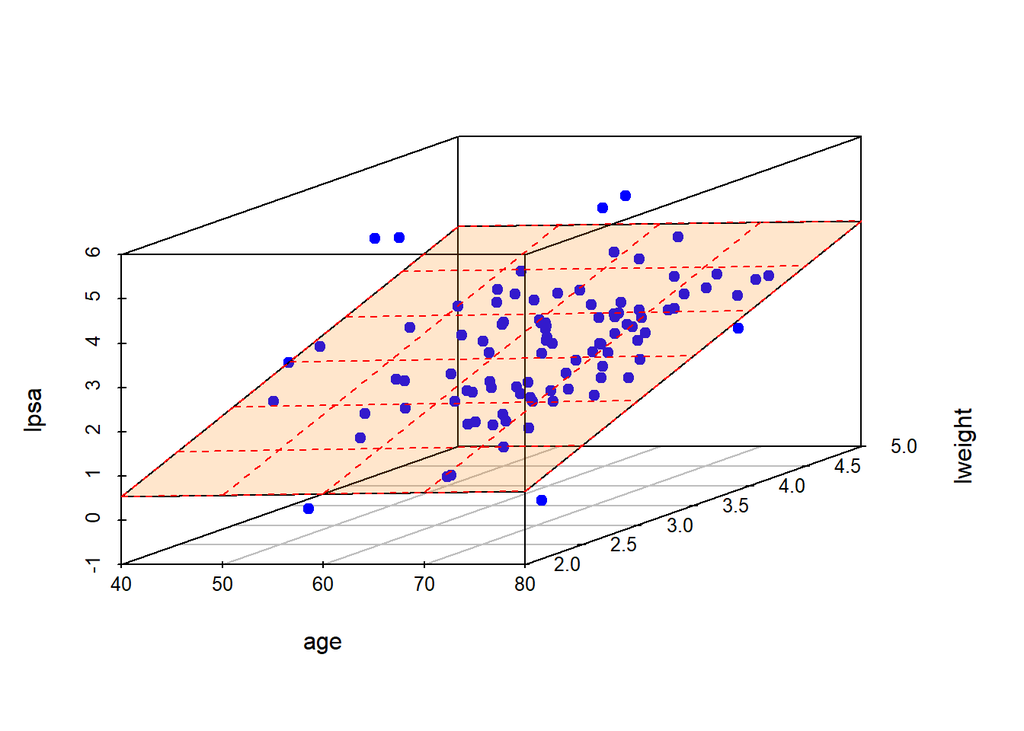

La regressió lineal múltiple és l’extensió natural de la regressió lineal simple en el cas qeu tinguem més d’una variable predictora.

L’eina matemàtica és la mateixa que hem fet servir en els dissenys ANOVA: El **model lineal**.

Dintre dels **models lineals**, i assumint que sempre tenim una variable resposta numèrica continua, tradicionalment parlem de:

- ANOVA: quan les variables explicatives són categòriques i estem interessats en veure com influeixen els diferents nivells en la variable resposta.
- REGRESSIÓ LINEAL MÚLTIPLE: quan tenim variables explicatives continues i el nostre objectiu principal és predir la variable resposta o quantificar la influència en ella de les diferents variables predictores.
- ANCOVA (Anàlisi de la covariància): És una fusió de les dues tècniques anteriors.

## 1.1 Dades utilitzades com a exemple

### 1.1.1 Descripció de les dades

Aquest conjunt de dades està inclòs al package **genridge**. Les dades provenen d’un estudi que va examinar la correlació entre el nivell d’antigen específic de la pròstata (psa) i una sèrie de mesures clíniques en homes que estaven a punt de rebre una prostatectomia radical.

-lcavol: log(cancer volume) en cc

-lweight: log(prostate weight) logaritme del pes en grams

-age: edat en anys

-lbph: log(benign prostatic hyperplasia amount)

-svi: seminal vesicle invasion **(aquesta variable dicotòmica (0|1) serà eliminada d’aquesta anàlisi)**

-lcp: log(capsular penetration)

-gleason: Gleason score

-pgg45: percentage Gleason scores 4 or 5

-lpsa: log(prostate specific antigen) logaritme de psa en ng per ml.

-train: **variable auxiliar eliminada d’aquesta anàlisi**

**L’objectiu és verificar la influència de diverses variables sobre el valor del psa (lpsa)**.

### 1.1.2 Càrrega i visualització de les dades

```r
library(genridge)
data("prostate")
prostate<-prostate[,-c(5,10)]
summary(prostate)
```

```
##      lcavol           lweight           age             lbph
##  Min.   :-1.3471   Min.   :2.375   Min.   :41.00   Min.   :-1.3863
##  1st Qu.: 0.5128   1st Qu.:3.376   1st Qu.:60.00   1st Qu.:-1.3863
##  Median : 1.4469   Median :3.623   Median :65.00   Median : 0.3001
##  Mean   : 1.3500   Mean   :3.629   Mean   :63.87   Mean   : 0.1004
##  3rd Qu.: 2.1270   3rd Qu.:3.876   3rd Qu.:68.00   3rd Qu.: 1.5581
##  Max.   : 3.8210   Max.   :4.780   Max.   :79.00   Max.   : 2.3263
##       lcp             gleason          pgg45             lpsa
##  Min.   :-1.3863   Min.   :6.000   Min.   :  0.00   Min.   :-0.4308
##  1st Qu.:-1.3863   1st Qu.:6.000   1st Qu.:  0.00   1st Qu.: 1.7317
##  Median :-0.7985   Median :7.000   Median : 15.00   Median : 2.5915
##  Mean   :-0.1794   Mean   :6.753   Mean   : 24.38   Mean   : 2.4784
##  3rd Qu.: 1.1787   3rd Qu.:7.000   3rd Qu.: 40.00   3rd Qu.: 3.0564
##  Max.   : 2.9042   Max.   :9.000   Max.   :100.00   Max.   : 5.5829
```

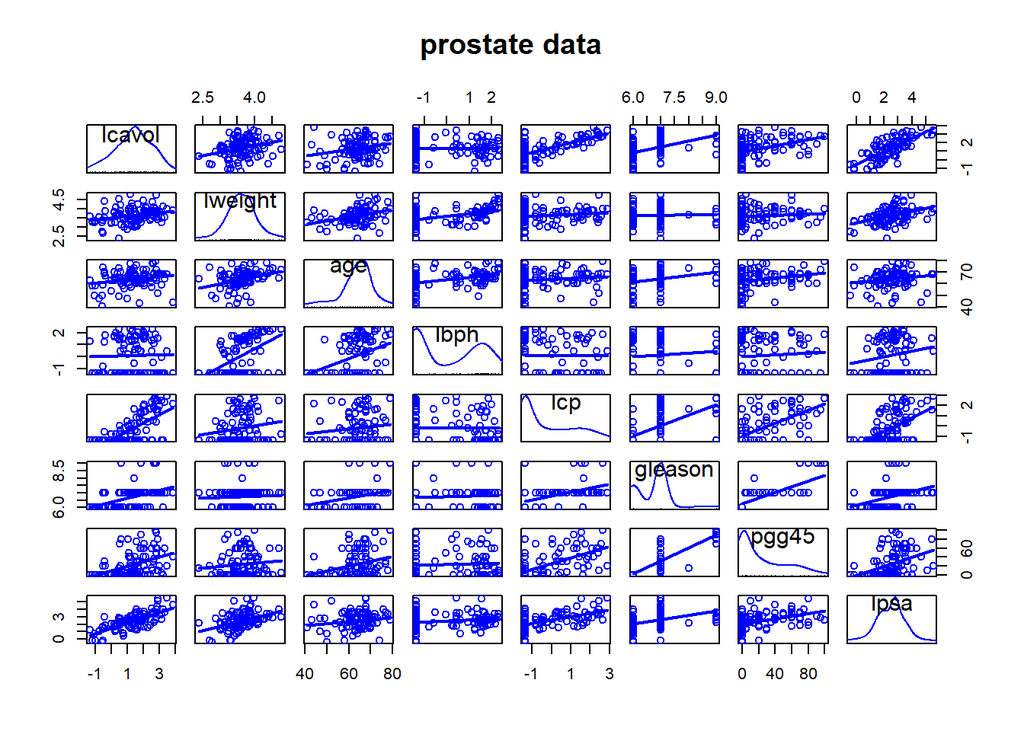

```r
library(car)
scatterplotMatrix(prostate,main = "prostate data",smooth=F)
```

## 1.2 Repàs de Regressió lineal simple

El model lineal és
$$Y_i = a + b X_i +
\epsilon_i$$
i l’objectiu és obtenir la millor recta estimada que minimitzi els errors de predicció.

$$\hat{Y_i} = a + b X_i$$
$$\epsilon_i = Y_i - \hat{Y}_i$$

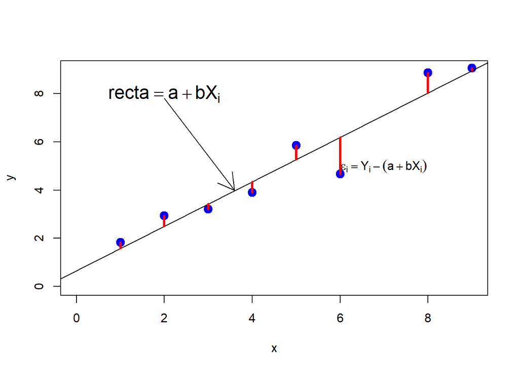

De fet volem minimitzar la suma d’errors quadràtics
$$SSE=\sum_{i=1}^n (Y_i - \hat{Y}_i
)^2=\sum_{i=1}^n (Y_i - (a + b X_i) )^2$$
Aplicant les tècniques de minimització (derivant i igualant a 0) obtenim:

$$\hat{b} = \frac{S_{XY}}{S_x^2}$$
i
$$\hat{a} = \bar{Y}-\hat{b}
\bar{X}$$

## 1.3 Model lineal per a la Regressió lineal Múltiple

$$Y_i=\beta_0+\beta_1X_{i1}+\beta_2X_{i2}+\cdots+\beta_pX_{ip}+\epsilon_i
\,\,\,\,\,\,\,\,\,\,\, i=1,...,n$$

En forma matricial $Y=X\beta+\epsilon$.

On
$$X = \left( \begin{array}{ccccc}
1 & X_{11} & X_{12} & ... & X_{1p} \\
1 & X_{21} & X_{22} & ... & X_{2p} \\
... & ... & ... & ... & ... \\
1 & X_{n1} & X_{n2} & ... & X_{np} \\ \end{array}
\right) \,\,\,
\beta=\left( \begin{array}{c} \beta_0 \\ \beta_1 \\ \beta_2 \\ \cdots
\\ \beta_p \\
\end{array} \right) \,\,\,
\epsilon=\left( \begin{array}{c} \epsilon_1 \\ \epsilon_2 \\ \cdots \\
\epsilon_n \\
\end{array} \right) \,\,\,
Y=\left( \begin{array}{c} Y_1 \\ Y_2 \\ \cdots \\ Y_n \\
\end{array} \right)$$

Els coeficients $\beta_i$ s’estimen seguint el criteri dels mínims quadrats, volem minimitzar la suma d’errors quadràtics

$$SSE=\sum_{i=1}^n (Y_i-(\beta_0 +
\beta_1 X_{i1}+ \beta_2 X_{i2}+ \cdots + \beta_p X_{ip}))^2$$

I es pot demostrar que el mínim s’obté a

$$\hat{\beta} =
(X^TX)^{-1}X^TY$$

### 1.3.1 Imatge gràfica de la regressió lineal múltiple

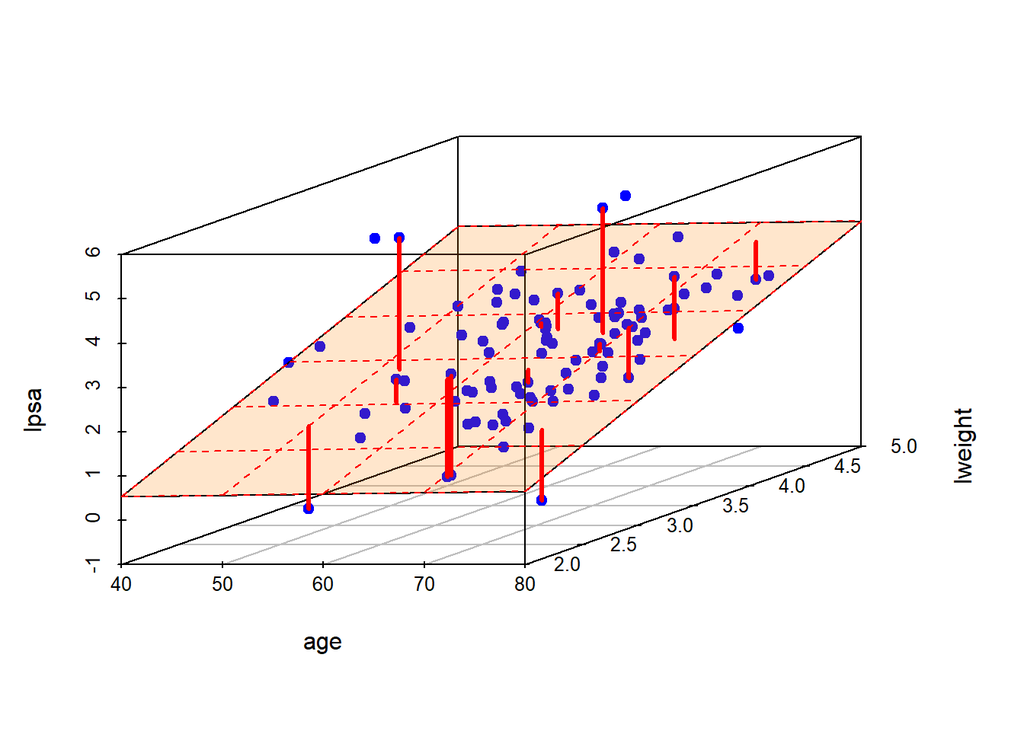

## 1.4 Ajust del model lineal

```r
prostate.lm<-lm(lpsa~.,data=prostate)
summary(prostate.lm)
```

```
##
## Call:
## lm(formula = lpsa ~ ., data = prostate)
##
## Residuals:
##      Min       1Q   Median       3Q      Max
## -1.45732 -0.40002 -0.03143  0.41678  1.80254
##
## Coefficients:
##              Estimate Std. Error t value Pr(>|t|)
## (Intercept)  0.422836   1.383227   0.306  0.76056
## lcavol       0.605602   0.091130   6.645 2.34e-09 ***
## lweight      0.667132   0.210248   3.173  0.00207 **
## age         -0.019872   0.011620  -1.710  0.09073 .
## lbph         0.069226   0.060072   1.152  0.25225
## lcp          0.012516   0.085668   0.146  0.88417
## gleason     -0.010314   0.161779  -0.064  0.94931
## pgg45        0.006198   0.004543   1.364  0.17599
## ---
## Signif. codes:  0 '***' 0.001 '**' 0.01 '*' 0.05 '.' 0.1 ' ' 1
##
## Residual standard error: 0.7339 on 89 degrees of freedom
## Multiple R-squared:  0.6252, Adjusted R-squared:  0.5958
## F-statistic: 21.21 on 7 and 89 DF,  p-value: < 2.2e-16
```

### 1.4.1 Interpretació dels coeficients

El model estimat és

lpsa=0.423 + 0.606 lcavol + 0.667 lweight + -0.02 age + 0.069 lbph + 0.013 lcp + -0.01 gleason + 0.006 pgg45

Els paràmetres s’interpreten com l’augment de la variable resposta quan la variable predictora corresponent s’incrementa en una unitat **si la resta de variables es mantenen constants**.

#### 1.4.1.1 Interpretació per l’edat

El valor estimat del paràmetre (pendent) és -0.02.

Un increment d’un any a la edat, provoca un descens del logaritme de la concentració de psa en 0.02 unitats.

#### 1.4.1.2 Interpretació pel pes de la pròstata

El pes ve expressat en logaritme dels grams (lweight).

El valor estimat del paràmetre (pendent) és 0.667.

Això vol dir que esperem un increment/decrement de 0.667 unitats del logaritme del psa per cada unitat d’increment en el logaritme del pes de la pròstata del pacient si la resta de variables es mantenen constants.

Tenint en compte els valors en logaritmes, això vol dir que si el pes del tumor es multiplica per $e^1 = 2.7183$, el logaritme de la concentració de psa s’incrementa en 0.667 unitats, es a dir la concentració de psa es multiplica per $e^{0.667} = 1.948$.

### 1.4.2 Resolució amb R de les equacions

```r
X<-as.matrix(prostate[,1:7])
ones<-rep(1,nrow(prostate))
X<-cbind(ones,X)
solve(t(X)%*%X)%*%t(X)%*%prostate[,8]
```

```
##                [,1]
## ones     0.42283645
## lcavol   0.60560187
## lweight  0.66713172
## age     -0.01987227
## lbph     0.06922597
## lcp      0.01251601
## gleason -0.01031416
## pgg45    0.00619760
```

És important notar que en regressió el nombre d’observacions ha de ser més gran que el nombre de variables predictores o no podran realitzar-se els càlculs matricials anteriors.

```r
prostate2<-prostate[1:5,]
X<-as.matrix(prostate2[,1:7])
ones<-rep(1,nrow(prostate2))
X<-cbind(ones,X)
solve(t(X)%*%X)%*%t(X)%*%prostate2[,8]
```

## 1.5 Anàlisi de la variància

Tal i com vam fer a l’ANOVA podem dividir el total de la variabilitat observada (SSTotal) en dos components additius:

- Variabilitat en Y explicada per la relació lineal amb $X_1, ..., X_p$. (SSR $SS_{Regression}$)
- Variabilitat en Y no explicada per la relació lineal amb $X_1, ..., X_p$. (SSE $SS_{Residual}$)

Aquesta darrera es mesura com la diferència entre cada $Y_i$ observat i el valor predit pel model de regressió.

### 1.5.1 Taula de l’Anàlisi de la variància per a una regressio lineal amb p predictors i n observacions

| Font de variació | Suma de quadrats | Graus de llibertat | Quadrats mitjans | Estadístic F |
| --- | --- | --- | --- | --- |
| Regressió | $SSR=\sum_{i=1}^n (\hat{Y}_i - \bar{Y})^2$ | $p$ | $MSR = \frac{SSR}{p}$ | $F = \frac{MSR}{MSE}$ |
| Error residual | $SSE=\sum_{i=1}^n (Y_i - \hat{Y}_i)^2$ | $n-p-1$ | $MSE = \frac{SSE}{n-p-1}$ |  |
| Total | $SST=\sum_{i=1}^n (Y_i - \bar{Y})^2$ | $n-1$ |  |  |

### 1.5.2 Càlcul de les sumes de quadrats

```r
SSR<-sum((prostate.lm$fitted.values-mean(prostate[,8]))^2)
SSE<-sum((prostate[,8]-prostate.lm$fitted.values)^2) #equivalentment prostate.lm$residuals%*%prostate.lm$residuals
MSR<-SSR/(ncol(prostate)-1)
MSE<-SSE/(nrow(prostate)-ncol(prostate))
c(SSR,SSE,MSR,MSE)
```

```
## [1] 79.9789468 47.9387121 11.4255638  0.5386372
```

El valor que apareix al summary del model lineal com *Residual standard error* correspon a l’arrel quadrada del MSE

```r
sqrt(MSE)
```

```
## [1] 0.7339191
```

Sota la suposició de que els residus del model es distribueixen segons una

$$\epsilon_i \sim
N(0,\sigma_E)$$

els valors esperats dels respectius quadrats mitjans són $\sigma_E^2$ per $MSE$ (Residual) i $\sigma_E^2$ més uns termes complexos, que inclouen els quadrats de tots els pendents de la regressió, per $MSR$ (Regressió). Això ens permet construir un contrast global sobre la regressió .

$$H_0: \beta_1 = \beta_2 = \cdots =
\beta_p = 0 \\
\mbox{ front l'alternativa } H_1: \exists i \mbox{ tal que } \beta_i
\ne 0$$

```r
F<-MSR/MSE
c(SSR,SSE,MSR,MSE,F)
```

```
## [1] 79.9789468 47.9387121 11.4255638  0.5386372 21.2119837
```

### 1.5.3 Hipòtesi global sobre la regressió

$$H_0: \beta_1 = \beta_2 = \cdots =
\beta_p = 0 \\
H_1: \exists i \mbox{ tal que } \beta_i \ne 0$$

```
##
## Call:
## lm(formula = lpsa ~ ., data = prostate)
##
## Residuals:
##      Min       1Q   Median       3Q      Max
## -1.45732 -0.40002 -0.03143  0.41678  1.80254
##
## Coefficients:
##              Estimate Std. Error t value Pr(>|t|)
## (Intercept)  0.422836   1.383227   0.306  0.76056
## lcavol       0.605602   0.091130   6.645 2.34e-09 ***
## lweight      0.667132   0.210248   3.173  0.00207 **
## age         -0.019872   0.011620  -1.710  0.09073 .
## lbph         0.069226   0.060072   1.152  0.25225
## lcp          0.012516   0.085668   0.146  0.88417
## gleason     -0.010314   0.161779  -0.064  0.94931
## pgg45        0.006198   0.004543   1.364  0.17599
## ---
## Signif. codes:  0 '***' 0.001 '**' 0.01 '*' 0.05 '.' 0.1 ' ' 1
##
## Residual standard error: 0.7339 on 89 degrees of freedom
## Multiple R-squared:  0.6252, Adjusted R-squared:  0.5958
## F-statistic: 21.21 on 7 and 89 DF,  p-value: < 2.2e-16
```

En aquest cas $F = \frac{11.4255638}{0.5386372}=21.2119837$.

### 1.5.4 Hipòtesis sobre cada coeficient de regressió

Sota les hipòtesis en que treballem

$$\hat{\beta} \sim
N(\beta,\sqrt((X^TX)^{-1} \sigma_E^2)).$$

Per contrastar $H_0: \beta_i = 0$ vs. $H_1: \beta_i \ne 0$ podem fer servir un estadístic $t$
$$t = \frac{b_i}{s_{b_i}}$$
que sota $H_0$ segueix una distribució t de Student amb n-(p+1) graus de llibertat.

Però és equivalent a comparar l’increment que suposa, en la variabilitat explicada, introduir el terme en qüestió front a no introduir-lo.

$H_0: \beta_{age} = 0$ vs. $H_1: \beta_{age} \ne 0$

```r
prostate.lm.full<-lm(lpsa~lcavol+lweight+age+lbph+lcp+gleason+pgg45 ,data=prostate)
prostate.lm.1<-lm(lpsa~lcavol+lweight+lbph+lcp+gleason+pgg45,data=prostate)
anova(prostate.lm.1,prostate.lm.full)
```

| Res.Df | RSS | Df | Sum of Sq | F | Pr(>F) |
| --- | --- | --- | --- | --- | --- |
| 90 | 49.51394 | NA | NA | NA | NA |
| 89 | 47.93871 | 1 | 1.575224 | 2.924463 | 0.0907304 |

En aquest cas $F = \frac{1.5752/1}{47.939/(97-7-1)}=1.5752/0.5386404 = 2.9244$.

$H_0: \beta_{lweight} = 0$ vs. $H_1: \beta_{lweight} \ne 0$

```r
prostate.lm.2<-lm(lpsa~lcavol+age+lbph+lcp+gleason+pgg45,data=prostate)
anova(prostate.lm.2,prostate.lm.full)
```

| Res.Df | RSS | Df | Sum of Sq | F | Pr(>F) |
| --- | --- | --- | --- | --- | --- |
| 90 | 53.36190 | NA | NA | NA | NA |
| 89 | 47.93871 | 1 | 5.423184 | 10.06834 | 0.002071 |

L’estadístic F mesura el canvi en la suma de quadrats residual per paràmetre addicional en el model més complet. Sota les hipòtesis del model i si la hipòtesi nul·la de que el model més simplificat és correcte, l’estadístic F segueix una distribució F de Fisher amb 1 i n-p-1 graus de llibertat.

Com veurem més endavant aquest resultat pot generalitzar-se per contrastar la significació simultània de diversos paràmetres i per tant per comparar entre si dos models jerarquitzats.

#### 1.5.4.1 Exemple d’un model amb cap terme individual significatiu

```
##
## Call:
## lm(formula = y ~ ., data = dades)
##
## Residuals:
##      Min       1Q   Median       3Q      Max
## -12.0800  -2.3457   0.1756   2.5376   8.6623
##
## Coefficients:
##             Estimate Std. Error t value Pr(>|t|)
## (Intercept)   -5.984      4.145  -1.444    0.152
## x1           -66.908     57.171  -1.170    0.245
## x2            59.436     40.851   1.455    0.149
## x3             9.072     44.049   0.206    0.837
##
## Residual standard error: 4.175 on 96 degrees of freedom
## Multiple R-squared:  0.1487, Adjusted R-squared:  0.1221
## F-statistic: 5.588 on 3 and 96 DF,  p-value: 0.001416
```

### 1.5.5 Relació entre summary(lm_object) i anova(lm_object) (Opcional)

```r
anova(prostate.lm)
```

|  | Df | Sum Sq | Mean Sq | F value | Pr(>F) |
| --- | --- | --- | --- | --- | --- |
| lcavol | 1 | 69.0028748 | 69.0028748 | 128.1064007 | 0.0000000 |
| lweight | 1 | 7.1726080 | 7.1726080 | 13.3162133 | 0.0004432 |
| age | 1 | 0.6456414 | 0.6456414 | 1.1986572 | 0.2765443 |
| lbph | 1 | 0.8089695 | 0.8089695 | 1.5018820 | 0.2236152 |
| lcp | 1 | 0.8089866 | 0.8089866 | 1.5019137 | 0.2236103 |
| gleason | 1 | 0.5376459 | 0.5376459 | 0.9981595 | 0.3204649 |
| pgg45 | 1 | 1.0022206 | 1.0022206 | 1.8606598 | 0.1759884 |
| Residuals | 89 | 47.9387121 | 0.5386372 | NA | NA |

```r
summary(prostate.lm)
```

```
##
## Call:
## lm(formula = lpsa ~ ., data = prostate)
##
## Residuals:
##      Min       1Q   Median       3Q      Max
## -1.45732 -0.40002 -0.03143  0.41678  1.80254
##
## Coefficients:
##              Estimate Std. Error t value Pr(>|t|)
## (Intercept)  0.422836   1.383227   0.306  0.76056
## lcavol       0.605602   0.091130   6.645 2.34e-09 ***
## lweight      0.667132   0.210248   3.173  0.00207 **
## age         -0.019872   0.011620  -1.710  0.09073 .
## lbph         0.069226   0.060072   1.152  0.25225
## lcp          0.012516   0.085668   0.146  0.88417
## gleason     -0.010314   0.161779  -0.064  0.94931
## pgg45        0.006198   0.004543   1.364  0.17599
## ---
## Signif. codes:  0 '***' 0.001 '**' 0.01 '*' 0.05 '.' 0.1 ' ' 1
##
## Residual standard error: 0.7339 on 89 degrees of freedom
## Multiple R-squared:  0.6252, Adjusted R-squared:  0.5958
## F-statistic: 21.21 on 7 and 89 DF,  p-value: < 2.2e-16
```

Fixem-nos que pel darrer terme de la taula $F=t^2$, però per la resta no és així. Però si demanem la suma de quadrats de tipus III

```r
car::Anova(prostate.lm,type='III',contrasts=c(unordered="contr.sum"))
```

|  | Sum Sq | Df | F value | Pr(>F) |
| --- | --- | --- | --- | --- |
| (Intercept) | 0.0503332 | 1 | 0.0934455 | 0.7605557 |
| lcavol | 23.7873739 | 1 | 44.1621433 | 0.0000000 |
| lweight | 5.4231845 | 1 | 10.0683434 | 0.0020710 |
| age | 1.5752244 | 1 | 2.9244626 | 0.0907304 |
| lbph | 0.7152983 | 1 | 1.3279779 | 0.2522512 |
| lcp | 0.0114972 | 1 | 0.0213449 | 0.8841736 |
| gleason | 0.0021894 | 1 | 0.0040646 | 0.9493087 |
| pgg45 | 1.0022206 | 1 | 1.8606598 | 0.1759884 |
| Residuals | 47.9387121 | 89 | NA | NA |

En tots els casos es verifica $F=t^2$ interpretant-se com l’efecte en la suma de quadrats residuals de la presència o absència de cada terme mantenint els altres.

### 1.5.6 Paradoxes

- Individualment una variable explicativa pot estar significativament relacionada amb la variable resposta, però no ser un predictor significatiu en el model de regressió lineal múltiple

```r
summary(lm(lpsa~pgg45,data=prostate))
```

```
##
## Call:
## lm(formula = lpsa ~ pgg45, data = prostate)
##
## Residuals:
##     Min      1Q  Median      3Q     Max
## -2.5652 -0.5862 -0.0354  0.6206  3.1803
##
## Coefficients:
##             Estimate Std. Error t value Pr(>|t|)
## (Intercept) 2.056967   0.141485  14.538  < 2e-16 ***
## pgg45       0.017284   0.003806   4.541 1.64e-05 ***
## ---
## Signif. codes:  0 '***' 0.001 '**' 0.01 '*' 0.05 '.' 0.1 ' ' 1
##
## Residual standard error: 1.052 on 95 degrees of freedom
## Multiple R-squared:  0.1784, Adjusted R-squared:  0.1697
## F-statistic: 20.62 on 1 and 95 DF,  p-value: 1.642e-05
```

- Una variable individualment pot NO estar significativament relacionada amb la variable resposta, però en un model de regressió lineal múltiple SÍ estar-ho
- El pendent d’una variable resposta pot canviar de signe si passem d’una regressió simple a múltiple. Recordem el pendent de *age* al model complet: -0.0198723.

```r
summary(lm(lpsa~age,prostate))
```

```
##
## Call:
## lm(formula = lpsa ~ age, data = prostate)
##
## Residuals:
##      Min       1Q   Median       3Q      Max
## -2.90738 -0.71234  0.06967  0.66187  2.99584
##
## Coefficients:
##             Estimate Std. Error t value Pr(>|t|)
## (Intercept)  0.79906    1.00793   0.793   0.4299
## age          0.02629    0.01568   1.677   0.0968 .
## ---
## Signif. codes:  0 '***' 0.001 '**' 0.01 '*' 0.05 '.' 0.1 ' ' 1
##
## Residual standard error: 1.144 on 95 degrees of freedom
## Multiple R-squared:  0.02876,    Adjusted R-squared:  0.01854
## F-statistic: 2.813 on 1 and 95 DF,  p-value: 0.09677
```

O el mateix amb la puntuació *Gleason*, que tenia com a coeficient -0.0103142, i en canvi

```r
summary(lm(lpsa~gleason,prostate))
```

```
##
## Call:
## lm(formula = lpsa ~ gleason, data = prostate)
##
## Residuals:
##      Min       1Q   Median       3Q      Max
## -2.78684 -0.76755 -0.01295  0.71322  2.95861
##
## Coefficients:
##             Estimate Std. Error t value Pr(>|t|)
## (Intercept)  -1.5044     1.0351  -1.453   0.1494
## gleason       0.5898     0.1524   3.869   0.0002 ***
## ---
## Signif. codes:  0 '***' 0.001 '**' 0.01 '*' 0.05 '.' 0.1 ' ' 1
##
## Residual standard error: 1.079 on 95 degrees of freedom
## Multiple R-squared:  0.1362, Adjusted R-squared:  0.1271
## F-statistic: 14.97 on 1 and 95 DF,  p-value: 0.0001999
```

### 1.5.7 Altres Hipòtesis

```r
prostate.lm.full<-lm(lpsa~lcavol+lweight+age+lbph+lcp+gleason+pgg45,data=prostate)
prostate.lm.2<-lm(lpsa~lcavol+lweight+age+lbph+lcp,data=prostate)
anova(prostate.lm.2,prostate.lm.full)
```

| Res.Df | RSS | Df | Sum of Sq | F | Pr(>F) |
| --- | --- | --- | --- | --- | --- |
| 91 | 49.47858 | NA | NA | NA | NA |
| 89 | 47.93871 | 2 | 1.539866 | 1.42941 | 0.2448934 |

En aquest cas les hipòtesis són

$$H_0: \beta_6 = \beta_7 = 0$$

front l’alternativa $H_1: \exists i=6,7$ tal que $\beta_i \ne 0$.

El contrast és

$$F =
\frac{1.5399/(7-5)}{47.939/(97-7-1)} = 0.76995 / 0.5386404
= 1.429432$$

En general calculem la suma de quadrats extra que implica introduir els paràmetres que es desitja contrastat respecte el model reduït

$$SS_{extra}=SSE_{reduced}-SSE_{full},$$

ho convertim en uns quadrats mitjans dividint pels graus de llibertat (increment en el número de paràmetres) i completem l’estadíst F

$$F = \frac{MSE_{extra}}{MSE_{full}}$$

segueix una distribució F de Fisher amb $p - p_0$ i $n-p-1$ graus de llibertat. On $p$ és el número de paràmetres del model més complet i $p_0$ en el model simplificat.

## 1.6 Variància explicada

La proporció de la variabilitat total de Y explicada pel model del regressió és

$$R^2 =
\frac{SS_{Regression}}{SS_{Total}}=1-\frac{SS_{Residual}}{SS_{Total}}$$

- Com més proper sigui $R^2$ a 1 més adequat serà el model.
- Com més proper a 0 pitjor. La variable resposta no s’ajusta **linealment** a les variables predictores.

Al nostre exemple SSR = 79.9789468 i SSE= 47.9387121. Obtenim per tant

```r
R2<-SSR/(SSR+SSE)
R2
```

```
## [1] 0.6252377
```

Fixem-nos que el coeficient $R^2$ pot obtenir-se també calculant el coeficient de correlació de Pearson entre els valors de la variable resposta i el valor predit pel model de regressión múltiple per a cada individu de la mostra i elevant al quadrat aquest darrer coeficient:

```r
R<-cor(prostate[,8],predict(prostate.lm))
R^2
```

```
## [1] 0.6252377
```

Aquest coeficient **R** també rep el nom de coeficient de correlació múltiple i també pot utilizar-se per mesurar la bondat del model de regressió.

$R^2$ no és una bona mesura per comparar models amb diferent nombre de variables explicatives. A mesura que afegim més predictors $R^2$ **sempre** s’incrementa.

Existeix una correcció que té en compte el nombre de predictors (adjusted $R^2$).

$$\bar{R}^2=1-(1-R^2) \frac{n-1}{n-p-1}=
R^2-(1-R^2) \frac{p}{n-p-1}$$

Al nostre exemple

```r
c(summary(prostate.lm)$r.squared,summary(prostate.lm)$adj.r.squared)
```

```
## [1] 0.6252377 0.5957620
```

## 1.7 Predicció i intervals de confiança

Podem obtenir intervals de confiança per l’estimació dels paràmetres del model

```r
confint(prostate.lm,level=0.95)
```

```
##                    2.5 %      97.5 %
## (Intercept) -2.325605350 3.171278242
## lcavol       0.424528183 0.786675561
## lweight      0.249372743 1.084890701
## age         -0.042961945 0.003217397
## lbph        -0.050136238 0.188588176
## lcp         -0.157704404 0.182736419
## gleason     -0.331766396 0.311138082
## pgg45       -0.002830228 0.015225429
```

Així com fer prediccions per noves observacions

```r
predict(prostate.lm,as.data.frame(prostate[1,1:7]))
```

```
##         1
## 0.7504742
```

```r
predict(prostate.lm,as.data.frame(prostate[1,1:7]),interval='confidence')
```

```
##         fit       lwr      upr
## 1 0.7504742 0.3381164 1.162832
```

```r
predict(prostate.lm,as.data.frame(prostate[1,1:7]),interval='prediction')
```

```
##         fit        lwr      upr
## 1 0.7504742 -0.7649875 2.265936
```

```r
new<-data.frame('lcavol'=2,'lweight'=3,'age'=60,'lbph'=-1.3,'lcp'=-1.3,'gleason'=7,'pgg45'=10)
predict(prostate.lm,new,interval='confidence')
```

```
##        fit      lwr      upr
## 1 2.326611 1.915457 2.737765
```

## 1.8 Diagnosi del model

L’estimació per intervals i els tests d’hipòtesis requereixen un conjunt de suposicions sobre els termes d’error del model.

1. Normalitat
2. Homocedasticitat
3. Independència

Aquestes suposicions poden ser comprovades a través dels gràfics o proves habituals sobre els residus del model

```r
shapiro.test(prostate.lm$residuals)
```

```
##
##  Shapiro-Wilk normality test
##
## data:  prostate.lm$residuals
## W = 0.98283, p-value = 0.2366
```

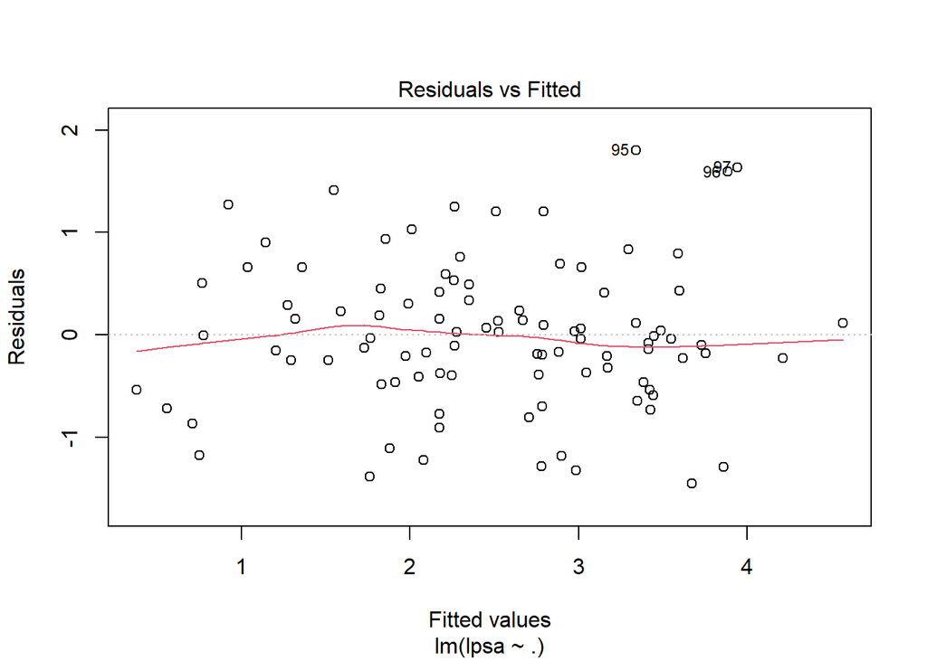

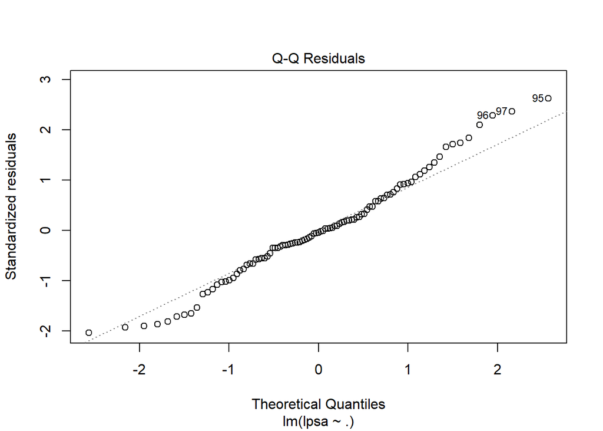

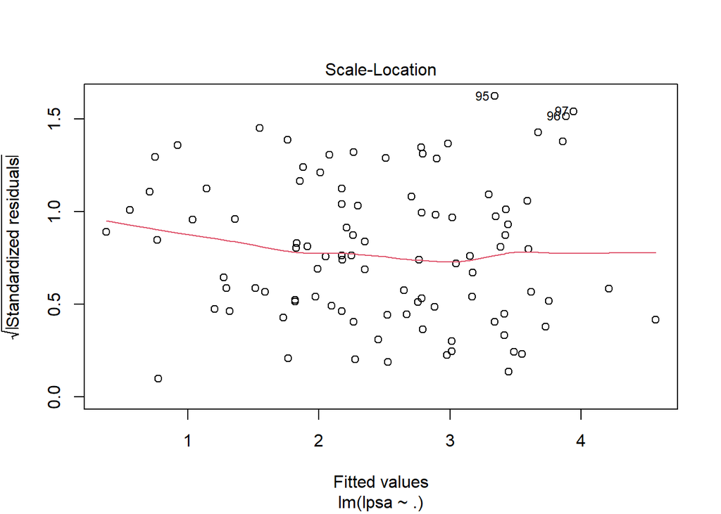

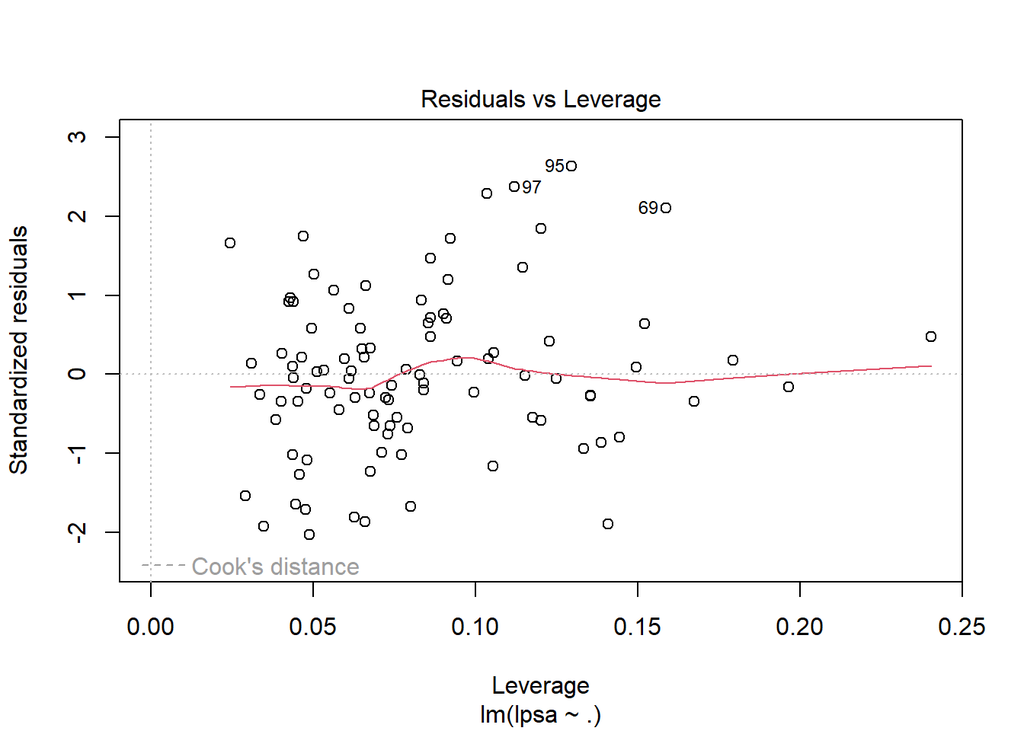

```r
plot(prostate.lm)
```

4. Presència d’observacions influents

El **leverage** pot ser considerat una mesura de com de lluny una observació es troba del centre de masses de les variables predictores, una mesura per quantificar l’anòmala (*outlier*) que és una observació. Es calcula $H=X(X^tX)^{-1}X^t$.

```r
H<-X%*%solve(t(X)%*%X)%*%t(X)
diag(H)
```

```
##          1          2          3          4          5          6          7
## 0.07995867 0.06753467 0.14450724 0.07720459 0.03478771 0.08282744 0.02912721
##          8          9         10         11         12         13         14
## 0.04762225 0.09944750 0.04018743 0.04522453 0.08606602 0.04576340 0.07920810
##         15         16         17         18         19         20         21
## 0.04813361 0.07373415 0.06584531 0.06274927 0.12280604 0.04798030 0.03863960
##         22         23         24         25         26         27         28
## 0.06602710 0.04387281 0.04455476 0.04385283 0.07230684 0.11770058 0.06512948
##         29         30         31         32         33         34         35
## 0.12026511 0.10551061 0.05508880 0.04042927 0.10570288 0.04262166 0.05026550
##         36         37         38         39         40         41         42
## 0.07108111 0.19649045 0.12012486 0.04896828 0.08555351 0.24038723 0.06172139
##         43         44         45         46         47         48         49
## 0.04640688 0.07596048 0.04357244 0.05122947 0.14094347 0.03361977 0.13543124
##         50         51         52         53         54         55         56
## 0.04960337 0.10390617 0.06862663 0.08627154 0.04362804 0.13346246 0.06732440
##         57         58         59         60         61         62         63
## 0.11459505 0.09024416 0.06115709 0.05958574 0.09106417 0.05802198 0.13880676
##         64         65         66         67         68         69         70
## 0.07301942 0.06753225 0.03110252 0.06892313 0.06287601 0.15871192 0.12487621
##         71         72         73         74         75         76         77
## 0.05323435 0.08616129 0.05632963 0.14949032 0.08417921 0.08415261 0.07324212
##         78         79         80         81         82         83         84
## 0.11540182 0.09431938 0.06116616 0.04703758 0.07862462 0.06461961 0.13542663
##         85         86         87         88         89         90         91
## 0.04293857 0.07424468 0.08333201 0.02432485 0.16732000 0.09232522 0.15220898
##         92         93         94         95         96         97
## 0.09148779 0.06624841 0.17939825 0.12970323 0.10351027 0.11205951
```

La **distància de Cook** és una mesura de la **influència que té un punt en la regressió**. Pot ser utilitzada per detectar punts amb forta influència. Es calcula a partir de la suma dels canvis que provoca en la predicció de la resta d’observacions l’eliminació del punt en qüestió. Es considera que 0.5 és un valor llindar a partir del qual pot ser perillosa la influència d’una observació.

$$D_i = \frac { \sum_{j=1}^n \left(
\hat{y}_j - \hat{y}_{j(i)} \right)^2 } {p s^2}$$
on $s^2$ és el MSE de la regressió.

### 1.8.1 Multicolinealitat

Un problema addicional és que les **variables predictores estiguin correlacionades entre elles**. Si es dóna aquest fet parlem de **Multicolinealitat** i pot influir en els resultats de la regressió de dues formes principals:

1. Fa inestables les estimacions dels coeficients del model.
2. Incrementa els errors estàndard dels pendents estimats i per tant els intervals de confiança són més imprecisos.

Ho podem il·lustrar amb les següents gràfiques. A la primera tenim dues variables predictores independents i grafiquem la suma de quadrats residual per diferents valors dels pendents. El model lineal real és $Y=3 X_1 + 4 X_2$.

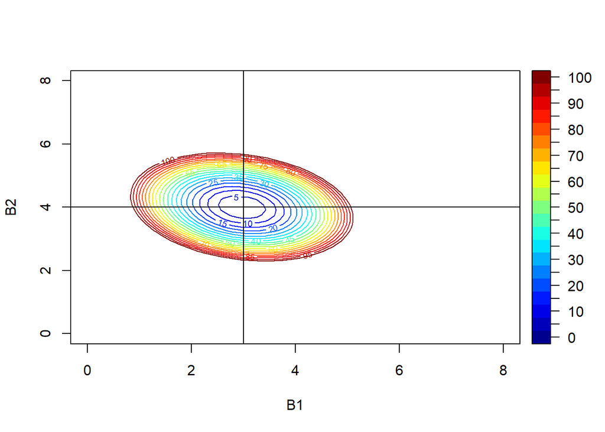

A la segona gràfica les variables predictores $X_1$ i $X_2$ estan fortament correlacionades

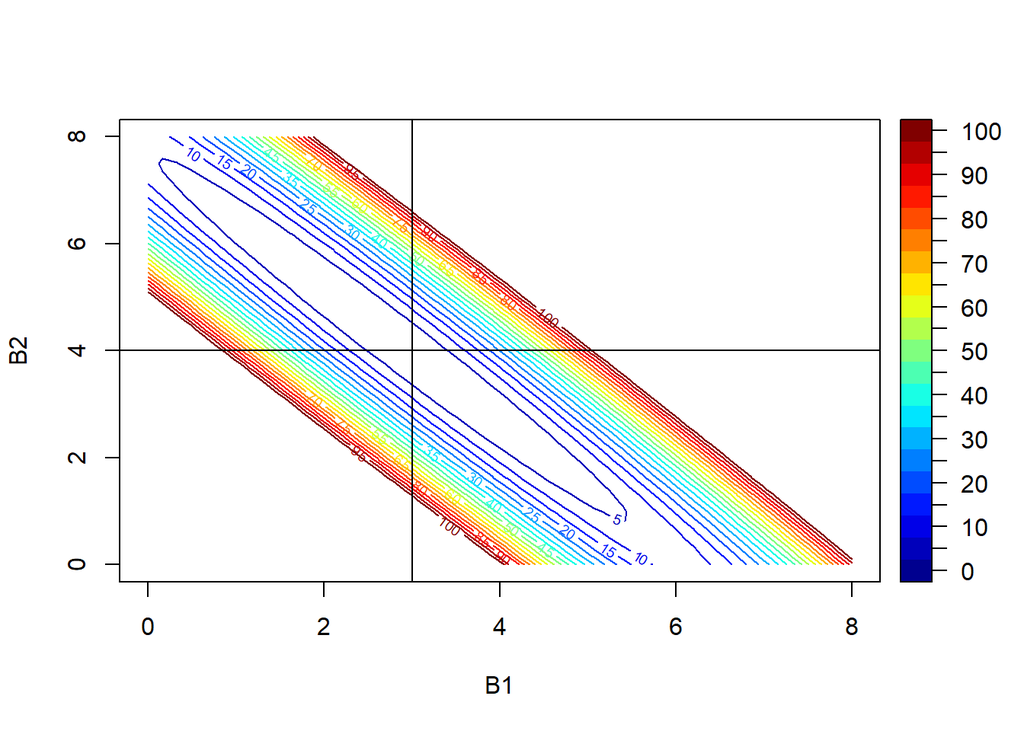

Per detectar la multicolinealitat pot analitzar-se la matriu de correlacions entre les variables predictores.

Numèricament

```r
cor(prostate[,1:7])
```

```
##            lcavol   lweight       age         lbph          lcp    gleason
## lcavol  1.0000000 0.2805214 0.2249999  0.027349703  0.675310484 0.43241706
## lweight 0.2805214 1.0000000 0.3479691  0.442264395  0.164537146 0.05688210
## age     0.2249999 0.3479691 1.0000000  0.350185896  0.127667752 0.26889160
## lbph    0.0273497 0.4422644 0.3501859  1.000000000 -0.006999431 0.07782045
## lcp     0.6753105 0.1645371 0.1276678 -0.006999431  1.000000000 0.51483006
## gleason 0.4324171 0.0568821 0.2688916  0.077820447  0.514830063 1.00000000
## pgg45   0.4336522 0.1073538 0.2761124  0.078460018  0.631528246 0.75190451
##              pgg45
## lcavol  0.43365225
## lweight 0.10735379
## age     0.27611245
## lbph    0.07846002
## lcp     0.63152825
## gleason 0.75190451
## pgg45   1.00000000
```

o gràficament

[figure not shown]

```r
library(corrgram)
corrgram(prostate[,1:7])
```

Però les correlacions dos a dos no sempre són definitives, podem tenir una forta colinealitat entre tres variables i no quedar reflectida en les correlacions per parelles.

Una possibilitat per determinar si la multicolinealitat suposa un problema és calcular la VIF (variance inflation) corresponent a cada variable. Un valor superior a 5 i sobre tot un valor superior a 10 suposa un greu problema de multicolinealitat.

El càlcul de la VIF sobre una variable predictora $X_i$ es realitza a partir de la fórmula

$$VIF=\frac{1}{1-R_i^2}$$

on $R_i^2$ és el coeficient de determinació de la regressió, on $X_i$ és la variable dependent i la resta de predictores actuen com a independents.

```r
vif(prostate.lm)
```

```
##   lcavol  lweight      age     lbph      lcp  gleason    pgg45
## 2.056129 1.445978 1.334034 1.353759 2.557297 2.432524 2.926695
```

Podeu trobar més informació i alguns suggeriments per aplicar en cas de multicolinealitat al següent [enllaç](http://en.wikipedia.org/wiki/Multicollinearity).

## 1.9 Mesura de la eficacia d’un model predictiu

Per quantificar la bondat real d’un model predictiu quan l’apliquem a noves dades es recomana quantificar la bondat de l’ajust sobre un conjunt de dades que no ha intervingut en l’estimació del model.

Anomenarem *dades d’entrenament* les que fem servir per estimar el model, i *dades de validació* les que fem servir per avaluar la bondat de la predicció.

### 1.9.1 Separació en un conjunt d’entrenament i un de validació

```r
set.seed(1234)
train = sample(1:nrow(prostate), nrow(prostate)/2)
trainP<-prostate[train,]
testP<-prostate[-train,]
dim(trainP) ## registres i columnes del conjunt d'entrenament
```

```
## [1] 48  8
```

### 1.9.2 Ajust del model sobre el conjunt d’entrenament

```r
fit1.lm<-lm(lpsa~.,trainP)
summary(fit1.lm)
```

```
##
## Call:
## lm(formula = lpsa ~ ., data = trainP)
##
## Residuals:
##     Min      1Q  Median      3Q     Max
## -1.3598 -0.3747 -0.0378  0.3078  1.3565
##
## Coefficients:
##              Estimate Std. Error t value Pr(>|t|)
## (Intercept) -0.354521   1.792212  -0.198  0.84419
## lcavol       0.595567   0.109683   5.430 2.98e-06 ***
## lweight      0.798208   0.248385   3.214  0.00259 **
## age         -0.021554   0.016586  -1.300  0.20119
## lbph         0.026345   0.080225   0.328  0.74433
## lcp         -0.097991   0.123824  -0.791  0.43339
## gleason      0.022607   0.211203   0.107  0.91529
## pgg45        0.009564   0.007168   1.334  0.18966
## ---
## Signif. codes:  0 '***' 0.001 '**' 0.01 '*' 0.05 '.' 0.1 ' ' 1
##
## Residual standard error: 0.6798 on 40 degrees of freedom
## Multiple R-squared:  0.6912, Adjusted R-squared:  0.6372
## F-statistic: 12.79 on 7 and 40 DF,  p-value: 1.725e-08
```

Efectuem les prediccions dels mateixos individus del conjunt d’entrenament

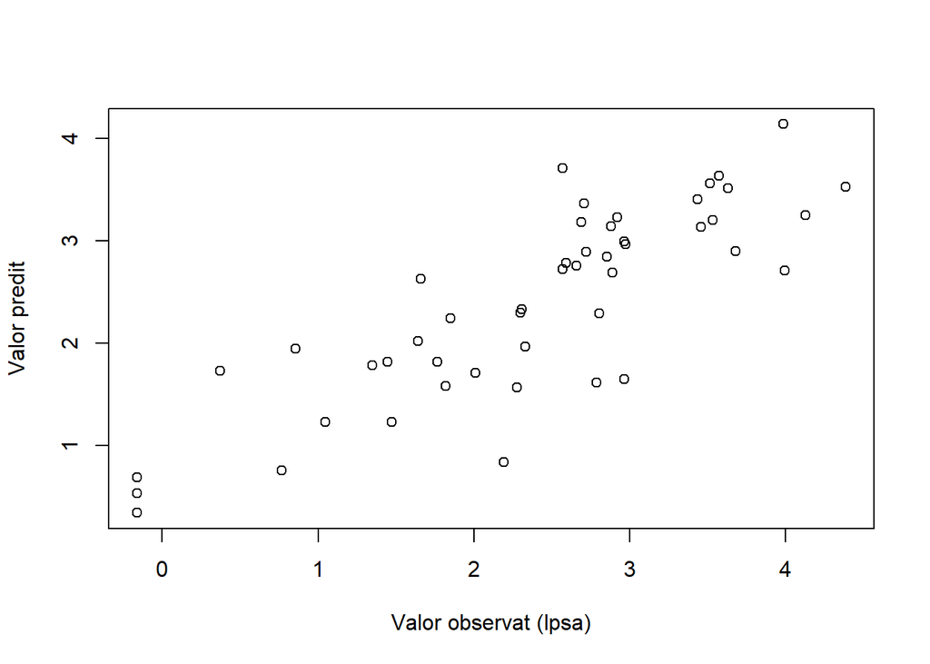

```r
pr1<-predict(fit1.lm)
plot(trainP$lpsa,pr1,xlab='Valor observat (lpsa)',ylab='Valor predit')
```

Calculem l’error quadràtic mig (MSE) estimat.

```r
mean((trainP$lpsa - pr1)^2)
```

```
## [1] 0.3851483
```

Però aquests valors són *massa optimistes* perquè està calculat amb els mateixos individus que hem utilitzat per construir el model.

El calcularem ara sobre el conjunt de validació que hem reservat,

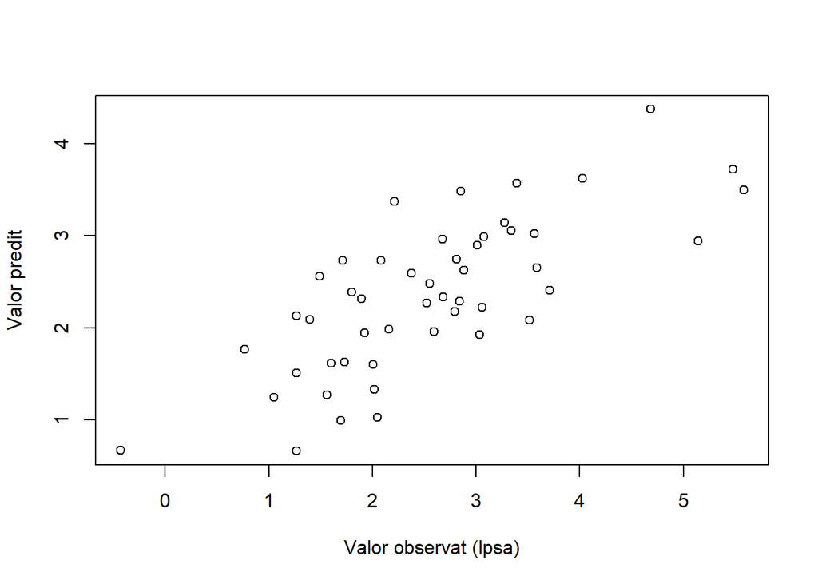

```r
pr2<-predict(fit1.lm,newdata=testP[,-8])
plot(testP$lpsa,pr2,xlab='Valor observat (lpsa)',ylab='Valor predit')
```

La $R^2$ calculada a partir de la correlació entre els valors predits i els reals és

```r
cor(pr2,testP[,8])^2
```

```
## [1] 0.5561455
```

i el valor mitjà dels errors quadràtics (MSE) és:

```r
mean((testP$lpsa - pr2)^2)
```

```
## [1] 0.6545486
```

Con veiem l’estimació de l’error és una mica més gran i considerem que aquesta és més propera a l’error que tindríem amb noves dades.

### 1.9.3 Validació creuada

Per aprofitar al màxim totes les dades, disposem de la tècnica de **validació creuada**, on dividim el conjunt original en diversos subconjunts i ajustem el model diverses vegades deixant fora cada cop a un subconjunt que utilitzem per estimar l’error i al final calculem el valor mitjà de tots els errors.

Esquemàticament

1. Particionem el conjunt de dades T en K subconjunts $T=(T_1,...,T_K)$ d’igual mida (Usualment K= 5 o K=10)
2. Per cada $i=1,2,...,K$ ajustem el model fent servir totes les dades excepte les de $T_i$.
3. Calculem els valors ajustats de les observacions de $T_i$ i l’error quadràtic.
4. L’error global és el valor mitjà dels errors per a cada grup.

Disposem de funcions en R que ens automatitzen aquests càlculs

```r
library(caret)
train.control <- trainControl(method = "cv", number = 10)
fit.cv<-train(lpsa~.,prostate,method='lm',trControl=train.control)
fit.cv
```

```
## Linear Regression
##
## 97 samples
##  7 predictor
##
## No pre-processing
## Resampling: Cross-Validated (10 fold)
## Summary of sample sizes: 86, 87, 88, 86, 88, 87, ...
## Resampling results:
##
##   RMSE    Rsquared   MAE
##   0.7587  0.5585411  0.5850968
##
## Tuning parameter 'intercept' was held constant at a value of TRUE
```

El package **caret** ens torna per defecte: l’arrel de l’error quadràtic mitjà (RMSE), la $R^2$ i l’error absolut mitjà (MAE).

#### 1.9.3.1 Leave-one-out cross-validation (LOOCV)

El cas portat al límit seria que cada cop deixéssim fora només una observació, i per tant, que féssim tants ajusts del model com dades a la mostra. Aquesta tècnica rep el nom de **Leave one out cross-validation (LOOCV)**.

```r
train.control <- trainControl(method = "LOOCV")
fit.cv<-train(lpsa~.,prostate,method='lm',trControl=train.control)
fit.cv
```

```
## Linear Regression
##
## 97 samples
##  7 predictor
##
## No pre-processing
## Resampling: Leave-One-Out Cross-Validation
## Summary of sample sizes: 96, 96, 96, 96, 96, 96, ...
## Resampling results:
##
##   RMSE       Rsquared   MAE
##   0.7681905  0.5549421  0.5861253
##
## Tuning parameter 'intercept' was held constant at a value of TRUE
```

## 1.10 Resum d’algunes funcions sobre els objectes lm

- **anova(lm.obj.1,lm.obj.2)**: comparació de models a través d’un ANOVA
- **coefficients(lm.obj)**: estimació puntual dels paràmetres (coeficients) del model
- **confint(lm.obj)**: intervals de confiança pels paràmetres del model
- **deviance(lm.obj)**: suma de quadrats dels residus (SSE)
- **df.residual(lm.obj)**: graus de llibertat dels residus
- **fitted(lm.obj)**: valors ajustats (prediccions) sobre les observacions
- **influence(lm.obj)**: diversos valors sobre la influència dels punts observats
- **predict(lm.obj,new=data.frame)**: prediccions sobre nous valors
- **residuals(lm.obj)**: valor dels residus
- **step(lm.obj)**: selecció automàtica de models a través del AIC
- **summary(lm.obj)**: llista dels principals estadístics del model
- **vcov(lm.obj)**: matriu de variàncies-covariàncies entre les estimacions dels paràmetres del model
- **vif(lm.obj)**: factors d’inflació de variància

### 1.10.1 Funcions gràfiques

- **avPlots(lm.obj)**: gràfics de les regressions parcials
- **plot(lm.obj)**: gràfics de diagnosi del model